# Math 5810 - Homework 5

Professor X

March 05, 2017

# Introduction

Using Hadley’s `bigvis` for the airline data 2013 to 2016

To use this code, first run the code in install-bigvis.R then unzip the file Airline.7z (I use 7-zip) into the folder `../Data/Airline`. You can adjust the folder relative to your desired working directory. Usually I assume the working directory is the home of `bigvis-06.R`

# Setup

```
##  setting  value
##  version  R version 3.3.2 (2016-10-31)
##  system   x86_64, linux-gnu
##  ui       X11
##  language en_US
##  collate  en_US.UTF-8
##  tz       America/Chicago
##  date     2017-03-05
```

```
## Packages ------------------------------------------------------------------
```

[output not shown]

```r
library(magrittr)   # pipe operators
library(data.table) # fast/effiecient read
library(tidyverse)  # loads dplyr, ggplot2, reshape2, etc.
                    # https://blog.rstudio.org/2016/09/15/tidyverse-1-0-0/
library(bigvis)
library(scales)
# library(grid)
```

# Get the Data

```r
fnames <- list.files(
    path       = '../../data/airline-cut'
  , full.names = T
  )
```

You should check that fnames contains the file names. Otherwise you have a problem with where you stored your data or the path name above

```r
fnames
```

```
##  [1] "../../data/airline-cut/2013_01.csv"
##  [2] "../../data/airline-cut/2013_02.csv"
##  [3] "../../data/airline-cut/2013_03.csv"
##  [4] "../../data/airline-cut/2013_04.csv"
##  [5] "../../data/airline-cut/2013_05.csv"
##  [6] "../../data/airline-cut/2013_06.csv"
##  [7] "../../data/airline-cut/2013_07.csv"
##  [8] "../../data/airline-cut/2013_08.csv"
##  [9] "../../data/airline-cut/2013_09.csv"
## [10] "../../data/airline-cut/2013_10.csv"
## [11] "../../data/airline-cut/2013_11.csv"
## [12] "../../data/airline-cut/2013_12.csv"
## [13] "../../data/airline-cut/2014_01.csv"
## [14] "../../data/airline-cut/2014_02.csv"
## [15] "../../data/airline-cut/2014_03.csv"
```

[output cut: 33 more lines]

Read in the contents of each file and combine them, then free up a bunch of memory by reassigning the initial list object we used to read in the data:

```r
flights <- lapply(
    X          = fnames
  , FUN        = data.table::fread
  , data.table = F
  )

flights %<>%
  bind_rows() %>%
  as_data_frame()
```

# Subset the data

The variables we will use are the following:

```r
flights %<>%
  select(
      DAY_OF_WEEK
    , DEP_TIME
    , ARR_TIME
    , ARR_DELAY
    , DEP_DELAY
    , AIR_TIME
    , DISTANCE
  )
```

Notice that some of the values are missing. You can remove them if you like using `flights = na.omit(flights)`. I’m using the original with missing values included:

```r
flights %>%
  is.na() %>%
  sum()
```

```
## [1] 1972450
```

Rename some columns for convenience:

```r
names(flights) <- c(
    'dayofweek'
  , 'deptime'
  , 'time'
  , 'delay'
  , 'depdelay'
  , 'airtime'
  , 'dist'
)
```

Add our calculated fields:

```r
flights %<>%
  mutate(
      speed = dist / (airtime / 60)
    , hours = floor(time / 100)
    , mins  = time - 100 * hours
    , time  = hours + (mins / 60)
  )
```

# Viz Creation

## Day with most flights

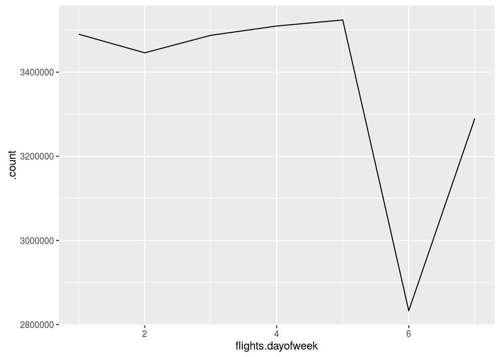

```r
dayofweek_sum <- bin(
    x     = flights$dayofweek
  , width = 1
  ) %>%
  condense()

dayofweek_sum %>%
  autoplot()
```

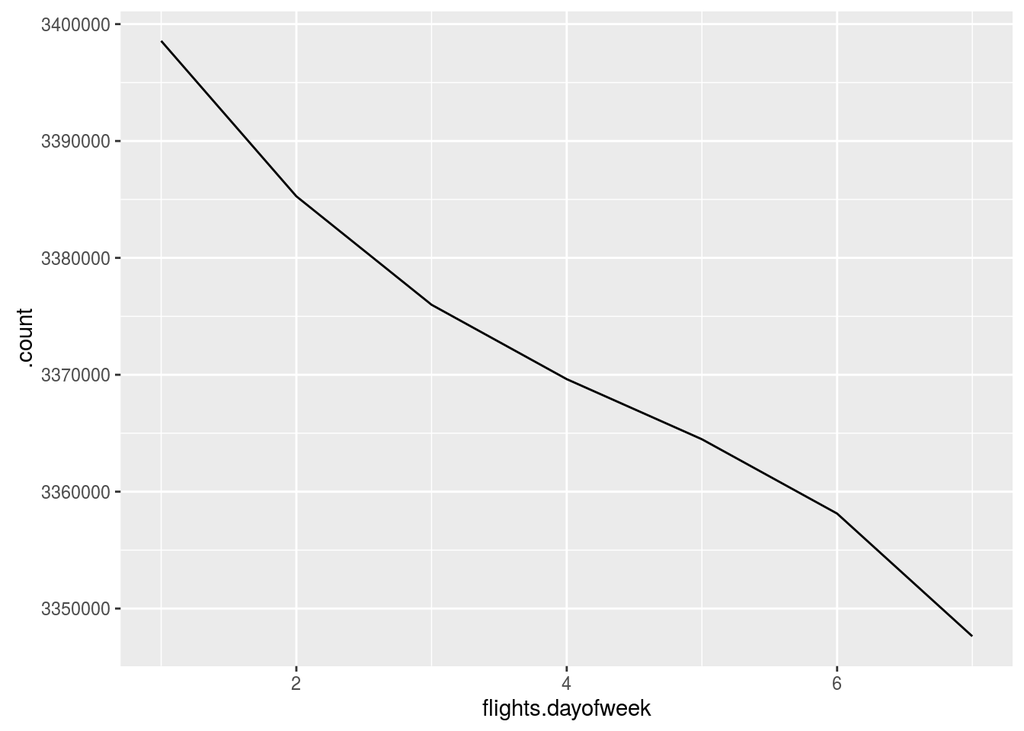

```r
dayofweek_sum %>%
  smooth(h = 10) %>%
  autoplot()
```

## Departure delays

This one is trying to show how many departure delays across the data and it seems like most made it out on time or earlier.

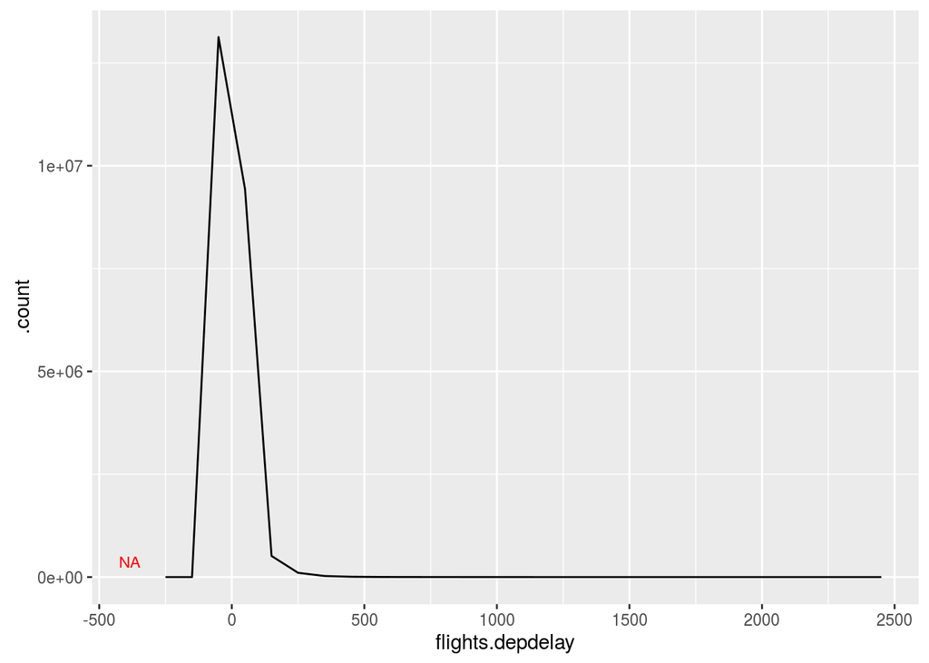

```r
depdelay_sum <- bin(
    x     = flights$depdelay
  , width = 100
  ) %>%
  condense()

depdelay_sum %>%
  autoplot()
```

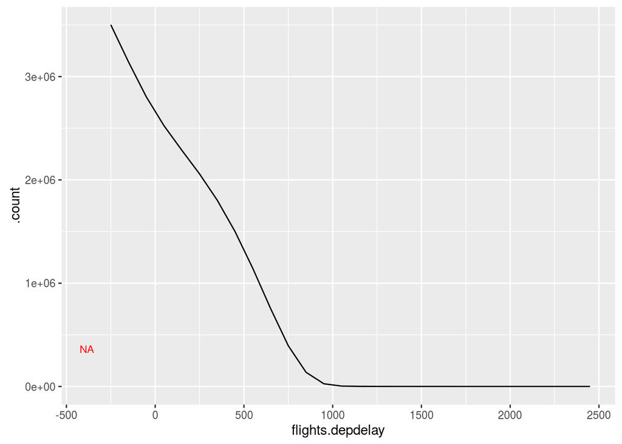

```r
depdelay_sum %>%
  smooth(h = 1000) %>%
  autoplot()
```

## On time departures by day of week

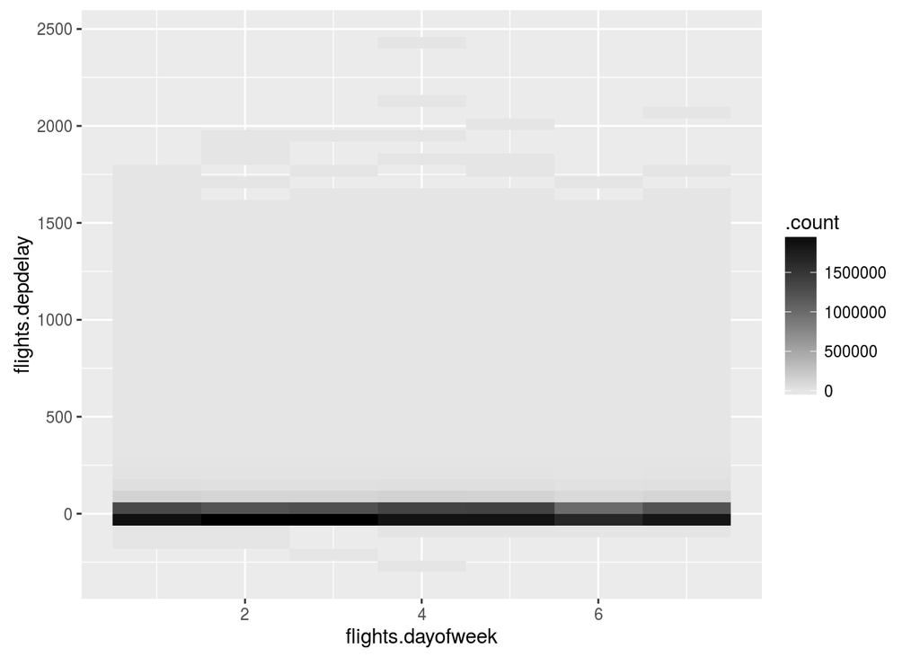

```r
daydelay <- condense(
    bin(flights$dayofweek, 1)
  , bin(flights$depdelay, 60)
  )

daydelay %>%
  autoplot()
```

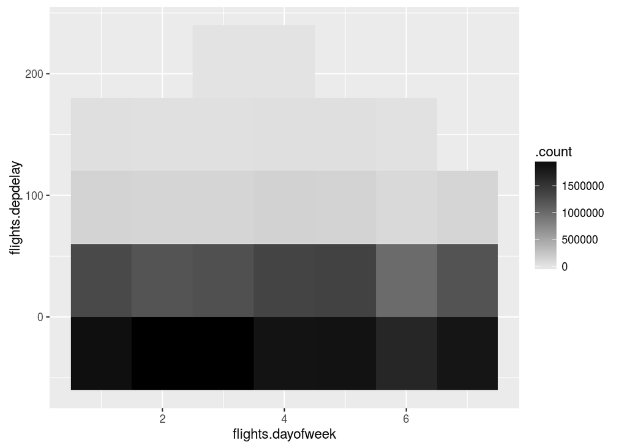

```r
daydelay %>%
  peel() %>%
  autoplot()
```

## Airtime

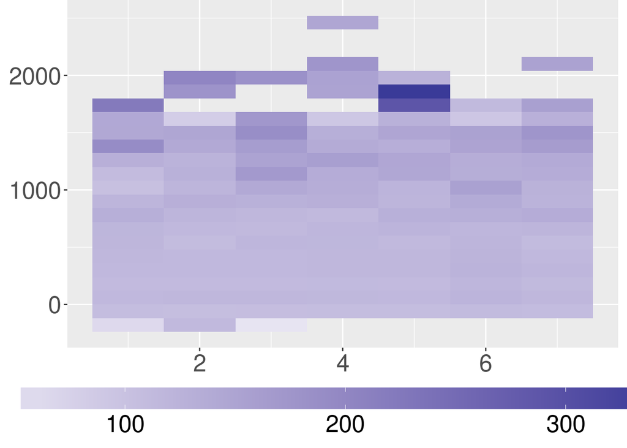

```r
teaser <- list(
    theme(
      legend.position  = "bottom"
    , plot.margin      = unit(c(0, 0.5, 0, 0.5), "lines")
    , legend.key.width = unit(1.45, "inches")
    , text             = element_text(size = 24)
  )
  , labs(
      x    = NULL
    , y    = NULL
    , fill = NULL
    )
)

daydeld <- condense(
    bin(flights$dayofweek, 1)
  , bin(flights$depdelay, 120)
  , z = flights$airtime
  )

daydeld %<>%
  subset(flights.dayofweek > 0)

daydeld %>%
  autoplot() + teaser
```

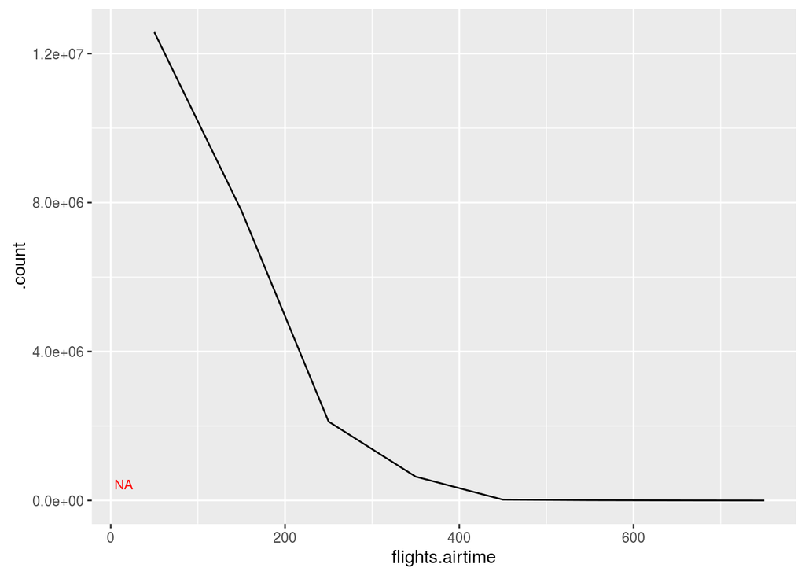

```r
airtime_sum <- bin(
    x     = flights$airtime
  , width = 100
  ) %>%
  condense()

airtime_sum %>%
  autoplot()
```

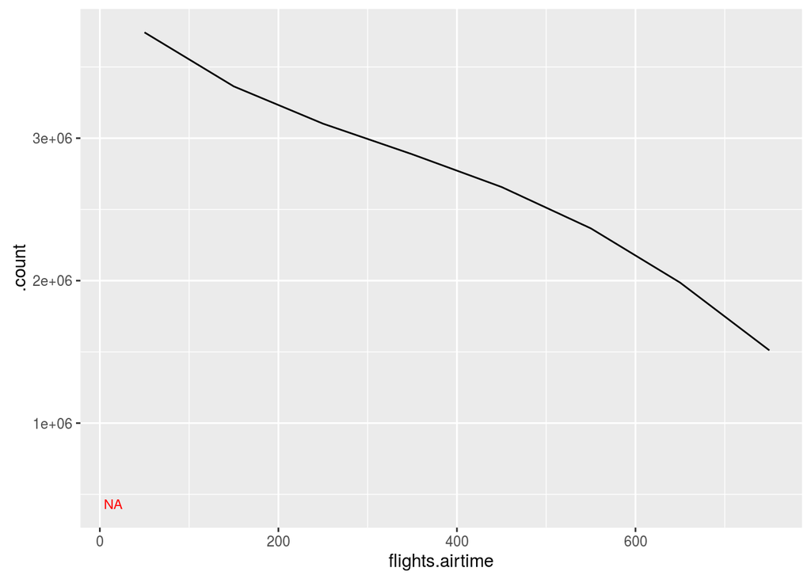

```r
airtime_sum %>%
  smooth(h = 1000) %>%
  autoplot()
```

## Airtime vs Departure delays

This one was comparing airtime and departure delay. It looks to me like the more airtime you have on a flight, the less likely you are to depart late.

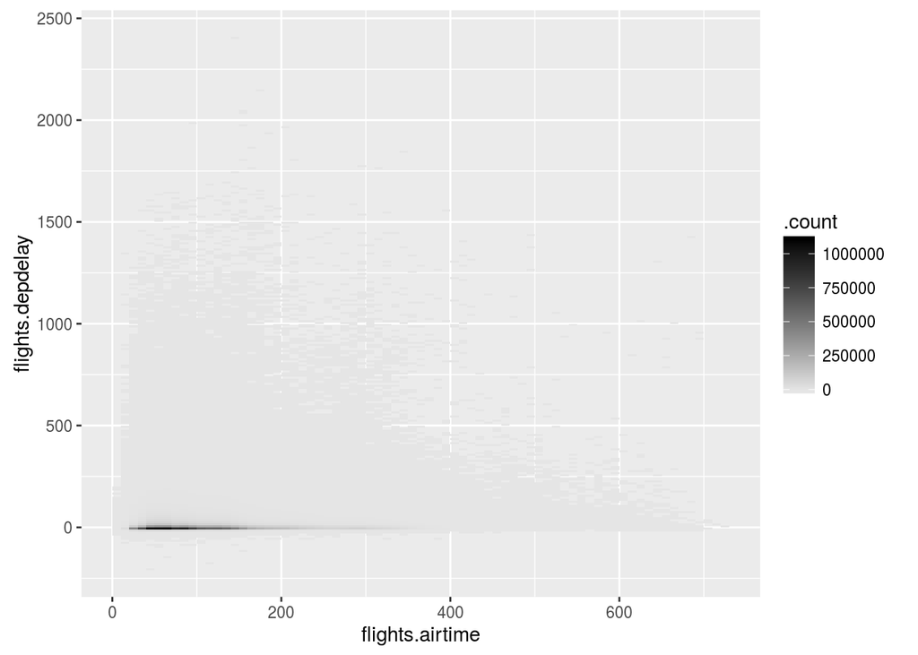

```r
airdelay <- condense(
    bin(flights$airtime, 10)
  , bin(flights$depdelay, 10)
  )

airdelay %>%
  autoplot()
```

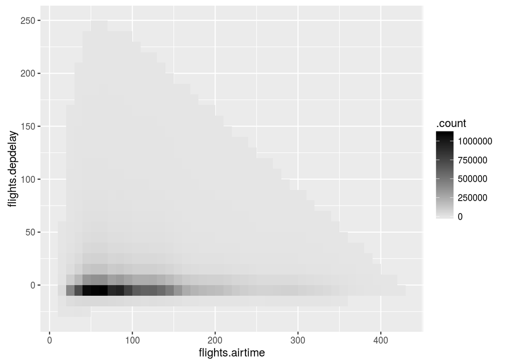

```r
airdelay %>%
  peel() %>%
  autoplot()
```

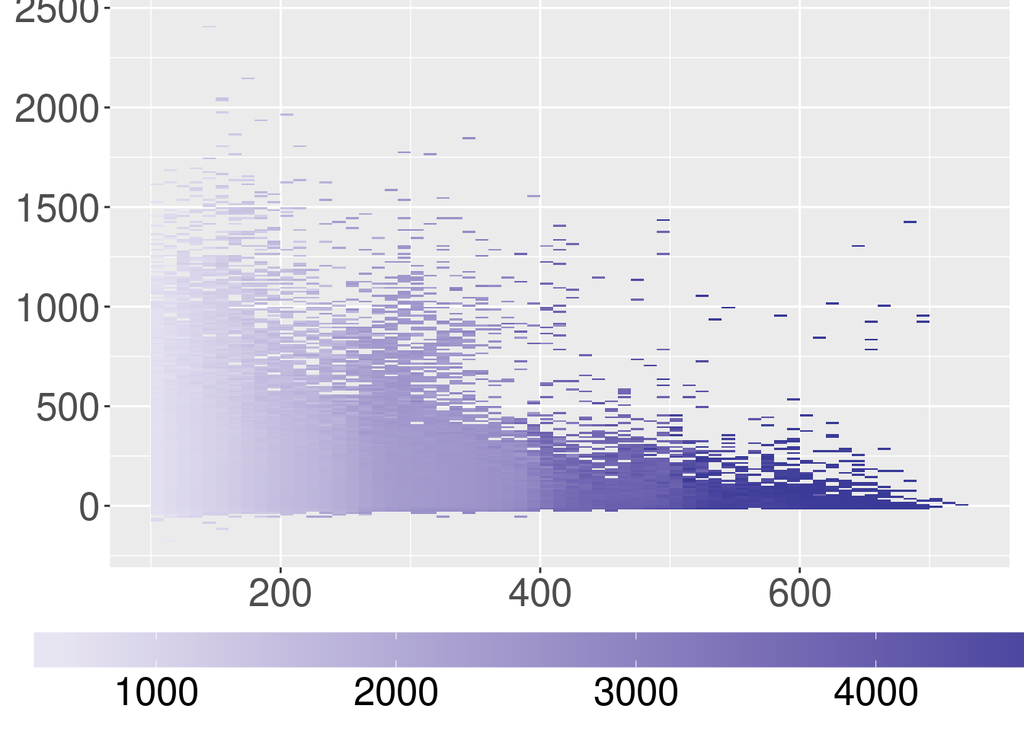

```r
airdelayd <- condense(
    bin(flights$airtime, 10)
  , bin(flights$depdelay, 10)
  , z = flights$dist
  )
airdelayd %<>%
  subset(flights.airtime > 100)

airdelayd %>%
  autoplot() + teaser
```